# Problem statement:

# Q-2: Print a heatmap to check NULL values. 1M

```python
# Checking total no. of NULL values for attributes specific
missingValue_Count=dataSetRead_New.isnull().sum()
print(missingValue_Count)
```

```
credit.policy         0
int.rate              0
installment           0
log.annual.inc        0
dti                   0
fico                  0
days.with.cr.line     0
revol.bal             0
revol.util            0
inq.last.6mths        0
delinq.2yrs           0
pub.rec               0
not.fully.paid        0
all_other             0
credit_card           0
debt_consolidation    0
educational           0
home_improvement      0
major_purchase        0
small_business        0
dtype: int64
```

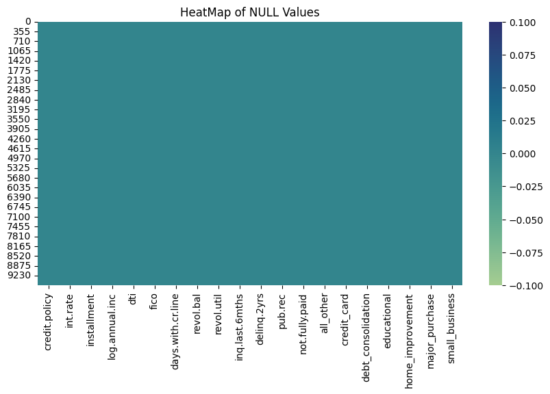

```python
# Import required packages
import matplotlib.pyplot as plt
import seaborn as sbn
plt.figure(figsize=(10,5))
sbn.heatmap(dataSetRead_New.isnull(),cmap="crest")
plt.title('HeatMap of NULL Values')
plt.show()
```

```python
# Checking duplicate values in dataSet
duplicatevalue_Count=dataSetRead_New.duplicated().sum()
print("Total duplicates values in dataSet:- {}".format(duplicatevalue_Count))
```

```
Total duplicates values in dataSet:- 0
```

```python
# Checking percentagewise distiribution for "not.fully.paid" target variable
dataSetRead_New['not.fully.paid'].value_counts(normalize=True).mul(100).round(2)
```

```
not.fully.paid
0    83.99
1    16.01
Name: proportion, dtype: float64
```

```python
# Cheking countwise distribution for "not.fully.paid" target variable
dataSetRead_New['not.fully.paid'].value_counts()
```

```
not.fully.paid
0    8045
1    1533
Name: count, dtype: int64
```

#### Analysis:-

Above distribution operation shows that dataset is unbalanced hence SMOTE technique need to be implemented for over sampling

## Split data in to features & target

```python
# Dropping target variable
X=dataSetRead_New.drop('not.fully.paid',axis=1)
# Taking target variavle
y=dataSetRead_New['not.fully.paid']
```

```python
# Importing SMOTE module from imblearn library
from imblearn.over_sampling import SMOTE
# Importing Counter module from collections library
from collections import Counter
counter = Counter(y)
print('Before oversampling', counter)
# Oversampling the dataset using SMOTE
smt = SMOTE(random_state = 2)
X_res, y_res = smt.fit_resample(X, y.ravel())
counter = Counter(y_res)
print('After oversampling', counter)
```

```
Before oversampling Counter({0: 8045, 1: 1533})
After oversampling Counter({0: 8045, 1: 8045})
```

# Q-3: Perform stratified splitting of train and test data. 1M

## Spliting the Data into Training and Testing Sets

```python
# Importing train_test_split package
from sklearn.model_selection import train_test_split
# Splitting train & test data
X_train,X_test,y_train,y_test=train_test_split(X_res,y_res,test_size=0.2,random_state=42,stratify=y_res)
```

```python
# Displaying dimenstion of train & test dataset
print('Shape of X_train = ', X_train.shape)
print('Shape of y_train = ', y_train.shape)
print('Shape of X_test = ', X_test.shape)
print('Shape of y_test = ', y_test.shape)
```

```
Shape of X_train =  (12872, 19)
Shape of y_train =  (12872,)
Shape of X_test =  (3218, 19)
Shape of y_test =  (3218,)
```

```python
# Converting a NumPy array to Pandas dataframe
y_test=pd.DataFrame(y_test,columns=['not.fully.paid'])
y_train=pd.DataFrame(y_train,columns=['not.fully.paid'])
```

```python
# Checking distiribution for "credit.policy" target variable in y_test
y_test.value_counts()
```

```
not.fully.paid
0                 1609
1                 1609
Name: count, dtype: int64
```

```python
# Checking distiribution for "credit.policy" target variable in y_train
y_train.value_counts()
```

```
not.fully.paid
0                 6436
1                 6436
Name: count, dtype: int64
```

## Data scaling

```python
# importing required package
# MinMax Scaler is used to perform feature scalling
from sklearn.preprocessing import MinMaxScaler
scalling=MinMaxScaler()
scalling.fit(X_train)
```

```
MinMaxScaler()
```

```python
X_train_scalling=scalling.transform(X_train)
X_test_scalling=scalling.transform(X_test)
```

# Q-4: Build a classifier model using the Decision Tree algorithm. 2M

```python
# Importing library of DecisionTreeClassifier
from sklearn.tree import DecisionTreeClassifier
# Creating instance of DecisionTreeClassifier
Classifiermodel_DTC_beforePruning = DecisionTreeClassifier()
```

```python
# Training the DecisionTreeClassifier model using training data set
Classifiermodel_DTC_beforePruning.fit(X_train_scalling, y_train)
```

```
DecisionTreeClassifier()
```

# Q-5: Print confusion matrix and classification report before and after pruning the Decision tree. (1+1)M

## Printing confusion matrix and classification report before pruning

```python
# Importing Library of classification_report, accuracy_score
from sklearn.metrics import classification_report, accuracy_score
# Importing required packages
from sklearn.metrics import confusion_matrix
```

```python
# Prediction on test data for DecisionTreeClassifier model
y_prediction_DTC_beforePruning=Classifiermodel_DTC_beforePruning.predict(X_test_scalling)
```

```python
# Evaluating the accuracy of DecisionTreeClassifier model
accuracy_DTC_beforePruning=accuracy_score(y_test,y_prediction_DTC_beforePruning)
print("DecisionTreeClassifier model accuracy before pruning: {}".format(round(accuracy_DTC_beforePruning,2)))
```

```
DecisionTreeClassifier model accuracy before pruning: 0.8
```

```python
# Evaluating classfication report for DecisionTreeClassifier model
report_DCT_beforePruning=classification_report(y_test,y_prediction_DTC_beforePruning)
print(report_DCT_beforePruning)
```

```
              precision    recall  f1-score   support

           0       0.80      0.79      0.80      1609
           1       0.79      0.81      0.80      1609

    accuracy                           0.80      3218
   macro avg       0.80      0.80      0.80      3218
weighted avg       0.80      0.80      0.80      3218
```

```python
# Evaluating confusion matrix for DecisionTreeClassifier model
conf_matrix_DCT_beforePruning=confusion_matrix(y_test,y_prediction_DTC_beforePruning)
print(conf_matrix_DCT_beforePruning)
```

```
[[1269  340]
 [ 309 1300]]
```

```python
falsePositive = conf_matrix_DCT_beforePruning.sum(axis=0) - np.diag(conf_matrix_DCT_beforePruning)
falseNegative = conf_matrix_DCT_beforePruning.sum(axis=1) - np.diag(conf_matrix_DCT_beforePruning)
truePositive = np.diag(conf_matrix_DCT_beforePruning)
trueNegative = conf_matrix_DCT_beforePruning.sum() - (falsePositive + falseNegative + truePositive)
print('************* DecisionTreeClassifier model before pruning *************')
for i in range(len(truePositive)):
    print(f"Class {i}:")
    print(f"truePositive: {truePositive[i]}, falsePositive: {falsePositive[i]}, falseNegative: {falseNegative[i]}, trueNegative: {trueNegative[i]}")
    print()
```

```
************* DecisionTreeClassifier model before pruning *************
Class 0:
truePositive: 1269, falsePositive: 309, falseNegative: 340, trueNegative: 1300

Class 1:
truePositive: 1300, falsePositive: 340, falseNegative: 309, trueNegative: 1269
```

## Printing confusion matrix and classification report after pruning

## Pre-Pruning with max_depth

```python
# Train Decision Tree with pre-pruning (using max_depth)
Classifiermodel_DTC_prePruning = DecisionTreeClassifier(random_state=42, max_depth=5)  # Adjust max_depth
Classifiermodel_DTC_prePruning.fit(X_train_scalling, y_train)
```

```
DecisionTreeClassifier(max_depth=5, random_state=42)
```

```python
# Prediction on test data for DecisionTreeClassifier model with pre-pruning
y_prediction_DTC_prePruning=Classifiermodel_DTC_prePruning.predict(X_test_scalling)
```

```python
# Evaluating the accuracy of DecisionTreeClassifier model with pre-pruning
accuracy_DTC_prePruning=accuracy_score(y_test,y_prediction_DTC_prePruning)
print("DecisionTreeClassifier model accuracy with pre-pruning: {}".format(round(accuracy_DTC_prePruning,2)))
```

```
DecisionTreeClassifier model accuracy with pre-pruning: 0.76
```

```python
# Evaluating classfication report for DecisionTreeClassifier model with pre-pruning
report_DCT_prePruning=classification_report(y_test,y_prediction_DTC_prePruning)
print(report_DCT_prePruning)
```

```
              precision    recall  f1-score   support

           0       0.74      0.79      0.76      1609
           1       0.77      0.73      0.75      1609

    accuracy                           0.76      3218
   macro avg       0.76      0.76      0.76      3218
weighted avg       0.76      0.76      0.76      3218
```

```python
# Evaluating confusion matrix for DecisionTreeClassifier model with pre-pruning
conf_matrix_DCT_prePruning=confusion_matrix(y_test,y_prediction_DTC_prePruning)
print(conf_matrix_DCT_prePruning)
```

```
[[1267  342]
 [ 439 1170]]
```

```python
falsePositiveprePruning = conf_matrix_DCT_prePruning.sum(axis=0) - np.diag(conf_matrix_DCT_prePruning)
falseNegativeprePruning = conf_matrix_DCT_prePruning.sum(axis=1) - np.diag(conf_matrix_DCT_prePruning)
truePositiveprePruning = np.diag(conf_matrix_DCT_prePruning)
trueNegativeprePruning = conf_matrix_DCT_prePruning.sum() - (falsePositiveprePruning + falseNegativeprePruning + truePositiveprePruning)
print('************* DecisionTreeClassifier model with prePruning*************')
for i in range(len(truePositiveprePruning)):
    print(f"Class {i}:")
    print(f"truePositive: {truePositiveprePruning[i]}, falsePositive: {falsePositiveprePruning[i]}, falseNegative: {falseNegativeprePruning[i]}, trueNegative: {trueNegativeprePruning[i]}")
    print()
```

```
************* DecisionTreeClassifier model with prePruning*************
Class 0:
truePositive: 1267, falsePositive: 439, falseNegative: 342, trueNegative: 1170

Class 1:
truePositive: 1170, falsePositive: 342, falseNegative: 439, trueNegative: 1267
```

# Cost-complexity pruning (Post-pruning)

```python
Classifiermodel_DTC_postPruning=DecisionTreeClassifier()
path = Classifiermodel_DTC_postPruning.cost_complexity_pruning_path(X_train_scalling, y_train)
ccp_alphas, impurities = path.ccp_alphas, path.impurities
```

```python
# Train a series of decision trees with different alpha values
pruned_models = []
for ccp_alpha in ccp_alphas:
    pruned_model = DecisionTreeClassifier(criterion="gini", ccp_alpha=ccp_alpha)
    pruned_model.fit(X_train_scalling, y_train)
    pruned_models.append(pruned_model)

# Find the model with the best accuracy on test data
best_accuracy = 0
best_pruned_model = None
for pruned_model in pruned_models:
    accuracy = pruned_model.score(X_test_scalling, y_test)
    if accuracy > best_accuracy:
        best_accuracy = accuracy
        best_pruned_model = pruned_model
# Model Accuracy after pruning
accuracy_after_pruning = best_pruned_model.score(X_test_scalling, y_test)
print("DecisionTreeClassifier model accuracy post pruning: {}".format(round(accuracy_after_pruning,2)))
```

```
DecisionTreeClassifier model accuracy post pruning: 0.81
```

```python
# Prediction on test data for DecisionTreeClassifier model post pruning
y_prediction_DTC_postPruning=best_pruned_model.predict(X_test_scalling)
```

```python
# Displaying classfication report for DecisionTreeClassifier model post pruning
report_DCT_postPruning=classification_report(y_test,y_prediction_DTC_postPruning)
print(report_DCT_postPruning)
```

```
              precision    recall  f1-score   support

           0       0.80      0.84      0.82      1609
           1       0.83      0.79      0.81      1609

    accuracy                           0.81      3218
   macro avg       0.81      0.81      0.81      3218
weighted avg       0.81      0.81      0.81      3218
```

```python
# Evaluating confusion matrix for DecisionTreeClassifier model with post pruning
conf_matrix_DCT_postPruning=confusion_matrix(y_test,y_prediction_DTC_postPruning)
print(conf_matrix_DCT_postPruning)
```

```
[[1347  262]
 [ 337 1272]]
```

```python
falsePositivepostPruning = conf_matrix_DCT_postPruning.sum(axis=0) - np.diag(conf_matrix_DCT_postPruning)
falseNegativepostPruning = conf_matrix_DCT_postPruning.sum(axis=1) - np.diag(conf_matrix_DCT_postPruning)
truePositivepostPruning = np.diag(conf_matrix_DCT_postPruning)
trueNegativepostPruning = conf_matrix_DCT_postPruning.sum() - (falsePositivepostPruning + falseNegativepostPruning + truePositivepostPruning)
print('************* DecisionTreeClassifier model with Post Pruning*************')
for i in range(len(truePositivepostPruning)):
    print(f"Class {i}:")
    print(f"truePositive: {truePositivepostPruning[i]}, falsePositive: {falsePositivepostPruning[i]}, falseNegative: {falseNegativepostPruning[i]}, trueNegative: {trueNegativepostPruning[i]}")
    print()
```

```
************* DecisionTreeClassifier model with Post Pruning*************
Class 0:
truePositive: 1347, falsePositive: 337, falseNegative: 262, trueNegative: 1272

Class 1:
truePositive: 1272, falsePositive: 262, falseNegative: 337, trueNegative: 1347
```

### Key Considerations:

Pre-pruning is easier to apply and more straightforward but may result in underfitting if the tree is pruned too early.

Post-pruning offers a more refined approach by growing the tree fully and then trimming unnecessary branches, but it requires more effort, such as determining the optimal value of ccp_alpha through cross-validation.

# Q-6 Plot the final decision tree model. 1M

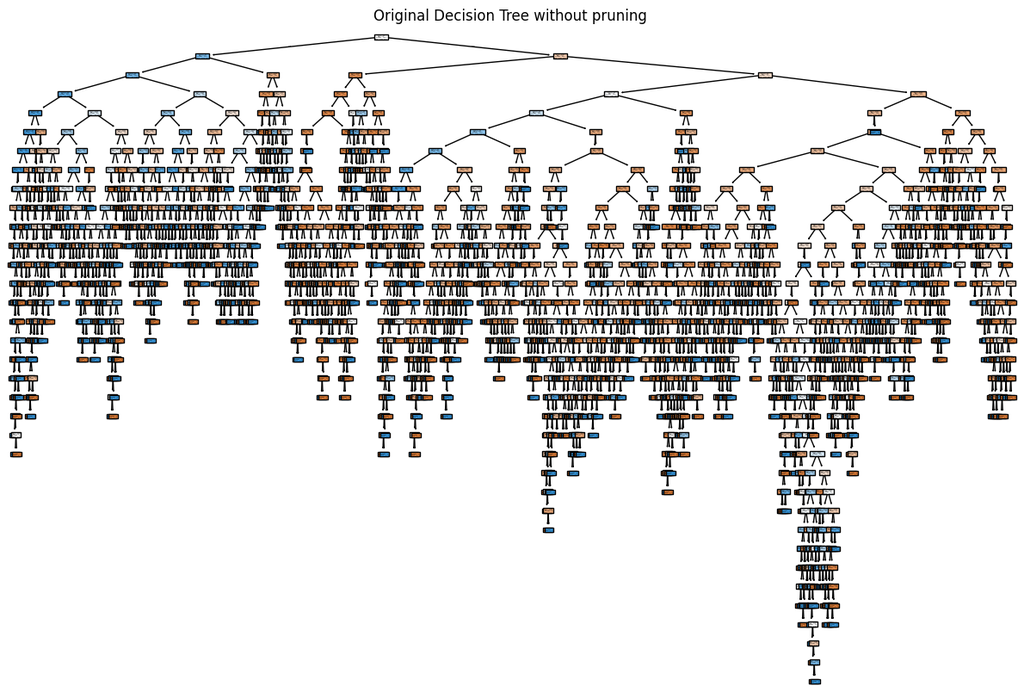

```python
from sklearn.tree import plot_tree
# Plot original tree
plt.figure(figsize=(15, 10))
plot_tree(Classifiermodel_DTC_beforePruning, filled=True)
plt.title("Original Decision Tree without pruning ")
plt.show()
```

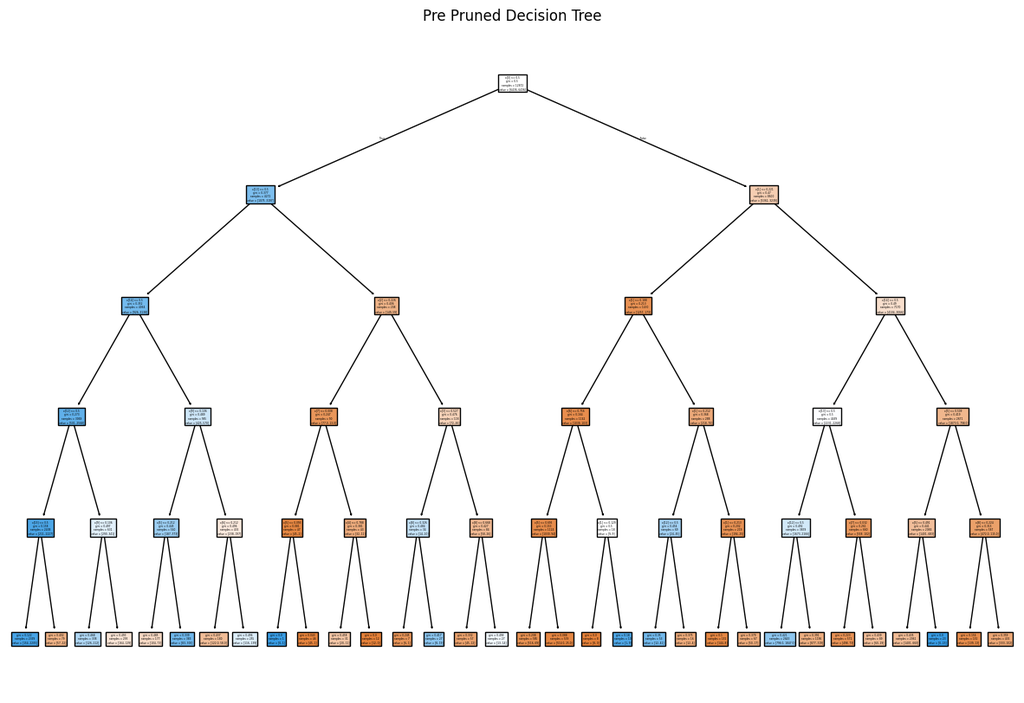

```python
# Plot pre pruned tree
plt.figure(figsize=(15, 10))
plot_tree(Classifiermodel_DTC_prePruning, filled=True)
plt.title("Pre Pruned Decision Tree")
plt.show()
```

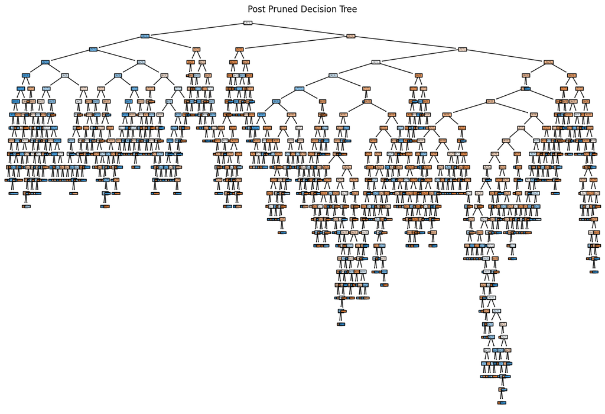

```python
# Plot post pruned tree
plt.figure(figsize=(15, 10))
plot_tree( best_pruned_model, filled=True)
plt.title("Post Pruned Decision Tree")
plt.show()
```

# Q-7: Find out the stratified cross-validation accuracy 1M

```python
# Importing required package
from sklearn.model_selection import cross_val_score, StratifiedKFold
```

```python
# Initialize the Decision Tree Classifier
Classifier_DST = DecisionTreeClassifier(random_state=42)

# Perform Stratified K-Fold Cross-Validation
# Here, we use 10 folds (cv=10)
stratified_kfold = StratifiedKFold(n_splits=10, shuffle=True, random_state=42)
cross_val_scores = cross_val_score(Classifier_DST, X_res, y_res, cv=stratified_kfold, scoring='accuracy')

# Print cross-validation accuracy scores and mean accuracy
print("Cross-Validation Accuracy Scores for each fold:")
print(cross_val_scores)

print("\nMean Stratified Cross-Validation Accuracy:")
print(cross_val_scores.mean())
```

```
Cross-Validation Accuracy Scores for each fold:
[0.81417029 0.80795525 0.80111871 0.79801119 0.81230578 0.82660037
 0.79552517 0.79303915 0.81852082 0.7998757 ]

Mean Stratified Cross-Validation Accuracy:
0.8067122436295836
```